# Bay Wheels (Ford GoBike) System Data

### by Wei Chong Ong

- Introduction
- Data Wrangling
- Feature Engineering
- Exploratory Data Analysis
  - Univariate Exploration
  - Bivariate Exploration
  - Multivariate Exploration

### Import all packages and set plots to be embedded inline

```python
import numpy as np
import pandas as pd
import matplotlib.pyplot as plt
import seaborn as sns

%matplotlib inline

import glob
```

## Introduction

### Investigation Overview

In this project, I investigated Bay Wheels (Ford GoBike) public datasets. [Bay Wheels](https://en.wikipedia.org/wiki/Bay_Wheels) is a regional public bicycle sharing system in California's San Francisco Bay Area.

The objective of this study is to investigate the bike activity patterns and the effects of trip characteristics on the average trip duration, for Bay Wheels's public bicycle sharing system during a seven-month period. Since April, Bay Wheels changed the structure of their public dataset by including the rideable type (electric or docked bike). Therefore, I used the data starting from April 2020 until October 2020 for consistency purpose. I downloaded the datasets for each months from its [website](https://www.lyft.com/bikes/bay-wheels/system-data) and concatenated them into one single master dataset.

### Dataset Overview

The dataset included information about individual rides made in a bike-sharing system covering three Californa's cities, San Francisco, San Jose and Oakland, for a seven months period, from April 2020 until October 2020. The data consisted of the location of the stations, the time the users picked up and returned the bike, user type and what type of bike they used for the trip. There are approximately 1 million data points. 1057 data points were removed from the analysis due to inconsistencies or missing information.

### Topics

I created visualizations and communicated the findings for the following topics:

1. When are most trips taken in terms of time of day or day of the week?
2. How long does the average trip take?
3. Does the average trip duration depend on
   - if a user is a subscriber (member) or customer (casual)?
   - if the bike used is a electric bike or a docked bike?
   - the time period a user picks up the bike?

### Import data

```python
df_master = pd.DataFrame()
for dataset in glob.glob('datasets_2020/*.csv'):
    df_master = pd.concat([df_master, pd.read_csv(dataset, index_col = 0)])

# Drop 'is_equity' column as it exists only in the 'May' dataset
df_master = df_master.drop('is_equity', axis=1)
df_master.reset_index(inplace=True)
```

## Data Wrangling

### Assess data

```python
df_master.info()
```

```
<class 'pandas.core.frame.DataFrame'>
RangeIndex: 999385 entries, 0 to 999384
Data columns (total 13 columns):
 #   Column              Non-Null Count   Dtype
---  ------              --------------   -----
 0   ride_id             999385 non-null  object
 1   rideable_type       999385 non-null  object
 2   started_at          999385 non-null  object
 3   ended_at            999385 non-null  object
 4   start_station_name  671714 non-null  object
 5   start_station_id    671714 non-null  float64
 6   end_station_name    653542 non-null  object
 7   end_station_id      653542 non-null  float64
 8   start_lat           999385 non-null  float64
 9   start_lng           999385 non-null  float64
 10  end_lat             997971 non-null  float64
 11  end_lng             997971 non-null  float64
 12  member_casual       999385 non-null  object
dtypes: float64(6), object(7)
memory usage: 99.1+ MB
```

```python
df_master.head()
```

|  | ride_id | rideable_type | started_at | ended_at | start_station_name | start_station_id | end_station_name | end_station_id | start_lat | start_lng | end_lat | end_lng | member_casual |
| --- | --- | --- | --- | --- | --- | --- | --- | --- | --- | --- | --- | --- | --- |
| 0 | C1625FB41A8A7211 | electric_bike | 2020-10-15 20:20:22 | 2020-10-15 21:25:22 | NaN | NaN | NaN | NaN | 37.72000 | -122.480000 | 37.720000 | -122.480000 | casual |
| 1 | 4EBA90C255647B88 | electric_bike | 2020-10-15 21:38:42 | 2020-10-15 22:29:09 | NaN | NaN | Eucalyptus Dr at 20th Ave | 540.0 | 37.72000 | -122.480000 | 37.731099 | -122.476259 | casual |
| 2 | 15F0AF77290C3633 | electric_bike | 2020-10-16 02:32:08 | 2020-10-16 02:46:00 | NaN | NaN | Harrison St at 20th St | 129.0 | 37.79000 | -122.420000 | 37.758872 | -122.412564 | casual |
| 3 | E9B0145885B8EFCF | electric_bike | 2020-10-15 19:19:04 | 2020-10-15 20:17:59 | Holloway Ave at Arellano Ave | 541.0 | NaN | NaN | 37.72096 | -122.478832 | 37.720000 | -122.480000 | casual |
| 4 | B536402782E8EF05 | electric_bike | 2020-10-16 16:22:25 | 2020-10-16 16:54:46 | Pierce St at Haight St | 73.0 | Powell St at Columbus Ave | 487.0 | 37.77182 | -122.433799 | 37.800436 | -122.410915 | casual |

```python
df_master[df_master['end_lat'].isnull()]['rideable_type'].value_counts()
```

```
docked_bike    1414
Name: rideable_type, dtype: int64
```

```python
df_master[df_master['start_station_id'].isnull()]['rideable_type'].value_counts()
```

```
electric_bike    327671
Name: rideable_type, dtype: int64
```

```python
df_master[df_master['end_station_id'].isnull()]['rideable_type'].value_counts()
```

```
electric_bike    344429
docked_bike        1414
Name: rideable_type, dtype: int64
```

> - Missing end station id in 1414 rows for docked bike: I assume that the trips start and end at the same station.
> - Two options for parking the electric bikes:
>   1. Place ebike in a dock at any Bay Wheels station
>   2. Use the cable to lock to any bike rack within the service area
> - Those missing ids for electric bike because they are locked using cable. So, there are only latitude and longitude coordinates available to track the its location.
> - For electric bike, the missing values of start station id and end station id are different. It means that there were some users picked up the bike at a docked station but returned the bike using the cable.

> Data Quality issue:
> - Incorrect datatypes: `started_at`, `ended_at`, `start_station_id`, `end_station_id`

### Clean data

```python
df_master_clean = df_master.copy()
```

```python
df_master_clean['started_at'] = pd.to_datetime(df_master_clean['started_at'])
df_master_clean['ended_at'] = pd.to_datetime(df_master_clean['ended_at'])
df_master_clean['start_station_id'] = df_master_clean['start_station_id'].astype(str)
df_master_clean['end_station_id'] = df_master_clean['end_station_id'].astype(str)
```

## Feature Engineering

#### Create `city` feature

```python
# Determine the city by looking at the longitudes
bin_edges = [-122.6, -122.3, -122.2, -121.7]
bin_labels = ['san_francisco', 'oakland', 'san_jose']
df_master_clean['city'] = pd.cut(df_master_clean['start_lng'], bin_edges, labels=bin_labels)
```

```python
df_master_clean['city'].isnull().sum()
```

```
0
```

#### Create `month_of_the_year` , `day_of_the_week`, `time_of_day` feature

```python
df_master_clean['month_of_the_year'] = df_master_clean['started_at'].dt.month
df_master_clean['day_of_the_week'] = df_master_clean['started_at'].dt.weekday
df_master_clean['week_period'] = df_master_clean['day_of_the_week'].map({0:'weekdays',
                                                                         1:'weekdays',
                                                                         2:'weekdays',
                                                                         3:'weekdays',
                                                                         4:'weekdays',
                                                                         5:'weekends',
                                                                         6:'weekends'})
df_master_clean['day_of_the_week'] = df_master_clean['day_of_the_week'].map({0:'Mon',
                                                                         1:'Tue',
                                                                         2:'Wed',
                                                                         3:'Thu',
                                                                         4:'Fri',
                                                                         5:'Sat',
                                                                         6:'Sun'})
```

```python
df_master_clean['pickup_hour'] = df_master_clean['started_at'].dt.hour
df_master_clean['return_hour'] = df_master_clean['ended_at'].dt.hour
```

#### Create `duration` feature in minute

```python
df_master_clean['duration'] = (df_master_clean['ended_at'] - df_master_clean['started_at']) / pd.Timedelta(minutes=1)
```

```python
# Only keep rows with positive ride_duration_in_min
df_master_clean = df_master_clean[df_master_clean['duration'] > 0]
```

```python
df_master_clean.info()
```

```
<class 'pandas.core.frame.DataFrame'>
Int64Index: 998328 entries, 0 to 999384
Data columns (total 20 columns):
 #   Column              Non-Null Count   Dtype
---  ------              --------------   -----
 0   ride_id             998328 non-null  object
 1   rideable_type       998328 non-null  object
 2   started_at          998328 non-null  datetime64[ns]
 3   ended_at            998328 non-null  datetime64[ns]
 4   start_station_name  670663 non-null  object
 5   start_station_id    998328 non-null  object
 6   end_station_name    652647 non-null  object
 7   end_station_id      998328 non-null  object
 8   start_lat           998328 non-null  float64
 9   start_lng           998328 non-null  float64
 10  end_lat             996921 non-null  float64
 11  end_lng             996921 non-null  float64
 12  member_casual       998328 non-null  object
 13  city                998328 non-null  category
 14  month_of_the_year   998328 non-null  int64
 15  day_of_the_week     998328 non-null  object
 16  week_period         998328 non-null  object
 17  pickup_hour         998328 non-null  int64
 18  return_hour         998328 non-null  int64
 19  duration            998328 non-null  float64
dtypes: category(1), datetime64[ns](2), float64(5), int64(3), object(9)
memory usage: 153.3+ MB
```

```python
df_master_clean.to_csv('bay_wheels_master.csv', index = False)
```

```python
bay_wheels_master = pd.read_csv('bay_wheels_master.csv')
```

```python
bay_wheels_master['started_at'] = pd.to_datetime(bay_wheels_master['started_at'])
bay_wheels_master['ended_at'] = pd.to_datetime(bay_wheels_master['ended_at'])
bay_wheels_master['start_station_id'] = bay_wheels_master['start_station_id'].astype(str)
bay_wheels_master['end_station_id'] = bay_wheels_master['end_station_id'].astype(str)
```

```python
days = pd.api.types.CategoricalDtype(ordered=True, categories=['Mon', 'Tue', 'Wed', 'Thu', 'Fri', 'Sat', 'Sun'])
bay_wheels_master['day_of_the_week'] = bay_wheels_master['day_of_the_week'].astype(days);
```

## Exploratory Data Analysis

### What is the structure of your dataset?

> The are 998328 ride activites in the cleaned dataset with 20 features containing the information about each individual rides.

### What is/are the main feature(s) of interest in your dataset?

> The `started_at` and `ended_at` are the main features in this project as they contain information about the time of day, day of the week, or month of the year. I'm most interested in figuring out what features play an important role in affecting the `duration` of the trip.

### What features in the dataset do you think will help support your investigation into your feature(s) of interest?

> These categorical features `rideable_type`, `city`, `member_casual`, `pickup_hour` will help me to determine which bike type is the more popular, which city has the most users, what type of users is using the service more often and what time of the day do the users pick up the bike.

## Univariate Exploration

> In this section, I investigate distributions of individual variables.

### Numeric Variables

```python
bay_wheels_master['duration'].describe()
```

```
count    998328.000000
mean         26.365114
std         345.031450
min           0.016667
25%           7.133333
50%          12.700000
75%          22.566667
max       54728.866667
Name: duration, dtype: float64
```

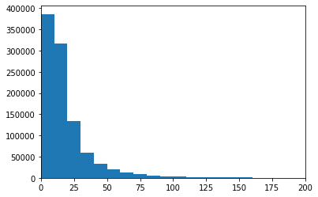

```python
bins = np.arange(0, bay_wheels_master['duration'].max() + 10, 10)
plt.hist(data = bay_wheels_master, x = 'duration', bins = bins)
plt.xlim(0,200);
```

`Duration` in the dataset take on a very large range of values, from about 0.017 min at the lowest, to about more than 50000 mins at the highest. Median is 12.7 mins and mean is 26.4 mins, which means that the data is right skewed. The 75 percentile is far lowest than the max value. So, it would better to visualize this kind of data by performing log transformation on the x-axis.

```python
np.log10(bay_wheels_master['duration']).describe()
```

```
count    998328.000000
mean          1.081176
std           0.471322
min          -1.778151
25%           0.853293
50%           1.103804
75%           1.353467
max           4.738216
Name: duration, dtype: float64
```

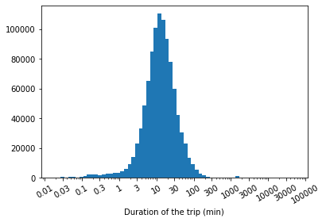

```python
# Get the ticks for bins between [0 - maximum weight]
bins = 10 ** np.arange(-1.77, 4.7+0.1, 0.1)

# Generate the x-ticks you want to apply
ticks = [0.01, 0.03, 0.1, 0.3, 1, 3, 10, 30, 100, 300, 1000, 3000, 10000, 30000, 100000]

# Convert ticks into string values, to be displayed along the x-axis
labels = ['{}'.format(v) for v in ticks]

# Plot the histogram
plt.hist(data = bay_wheels_master, x = 'duration', bins = bins)
# sns.distplot(bay_wheels_master['duration'], bins = bins, kde = False)
plt.xscale('log')

# Apply x-ticks
plt.xticks(ticks, labels, rotation = 30)

# Apply labels
plt.xlabel('Duration of the trip (min)');
```

> Plotted on a logarithmic scale, the distribution of durations takes on a unimodal shape. From this distribution we can clearly see that the average trip duration is about 12.7 mins.

### Categorical Variables

```python
categorical_vars = ['rideable_type', 'member_casual', 'city', 'month_of_the_year', 'day_of_the_week']
base_color = sns.color_palette()[0]
```

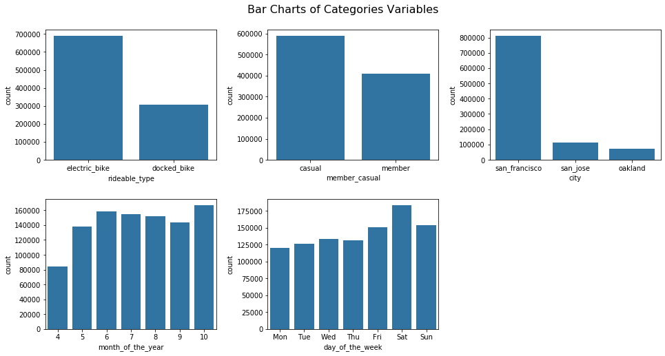

```python
fig = plt.figure(figsize=(16,8))
fig.subplots_adjust(wspace=0.3, hspace=0.3)
i=1
for cat in categorical_vars:
    ax = fig.add_subplot(2, 3, i)
    ax = sns.countplot(data = bay_wheels_master, x = cat, color=base_color)
    i+=1
fig.suptitle('Bar Charts of Categories Variables', ha='center', va='center', fontsize=16, y=0.93);
```

> - The number of electric bike used is more than twice the number of docked bike.
> - Interestingly, there are more riding activity of casual users (non-member) than the member users.
> - The majority of the users are in San Francisco, with 8 times more than Oakland and San Jose.
> - Over the year of 2020, more and more people were using the bicycle sharing system in California. From April to October, the number of users has doubled.
> - Saturday has the highest number of trips compared to other days.

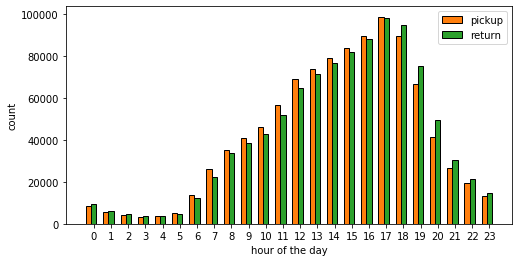

```python
pickup_hour = bay_wheels_master.groupby('pickup_hour').count()['ride_id']
return_hour = bay_wheels_master.groupby('return_hour').count()['ride_id']

fig, ax = plt.subplots(figsize=(8,4))
ind = np.arange(24)  # the x locations for the groups
width = 0.3   # the width of the bars
bars1 = ax.bar(ind, pickup_hour, width, color = sns.color_palette()[1], edgecolor = 'black', label='pickup')
bars2 = ax.bar(ind + width, return_hour, width, color = sns.color_palette()[2], edgecolor = 'black', label='return')
ax.set_ylabel('count')
ax.set_xlabel('hour of the day')
locations = ind + width # xtick locations
labels = ['{}'.format(v) for v in ind]
ax.set_xticks(locations)
ax.set_xticklabels(labels)
ax.legend()
plt.show()
```

> - Since majority of the users return the bike within 60 mins, the pickup and return hour show similar pattern.
> - This pattern surprised me as I would expect there are two peaks, start work time and off-work time. However, we could clearly see that there is only one peak during the off-work period. The number of rides increases gradually from 5am until the evening with the peak at 5pm. By comparing the number of pickups and returns throughout the day, visible are that people are picking up the bike more in the moring and returning the bike more in the everning.

### Discuss the distribution(s) of your variable(s) of interest. Were there any unusual points? Did you need to perform any transformations?

> The distribution is right skewed due to the very large range of values. I needed to perform log transformation on the x-axis to have a better visualization.

### Of the features you investigated, were there any unusual distributions? Did you perform any operations on the data to tidy, adjust, or change the form of the data? If so, why did you do this?

> I created new columns using the original columns `started_at` and `ended_at` to extract the pickup and return hour, day of the week and month of the year. Furthermore, I removed all negative values of `duration`.

## Bivariate Exploration

> In this section, I investigate relationships between pairs of variables in the data.

```python
def log_trans(x, inverse = False):
    if not inverse:
        return np.log10(x)
    else:
        return np.power(10, x)

bay_wheels_master['log_duration'] = bay_wheels_master['duration'].apply(log_trans)
```

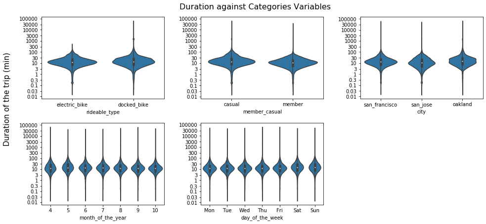

```python
ticks = [0.01, 0.03, 0.1, 0.3, 1, 3, 10, 30, 100, 300, 1000, 3000, 10000, 30000, 100000]
labels = ['{}'.format(v) for v in ticks]

fig = plt.figure(figsize=(16,7))
fig.subplots_adjust(wspace=0.3, hspace=0.3)
i=1
for cat in categorical_vars:
    ax = fig.add_subplot(2, 3, i)
    ax = sns.violinplot(data = bay_wheels_master, x = cat, y = 'log_duration', color = base_color)
    ax.set_yticks(log_trans(ticks))
    ax.set_yticklabels(labels)
    ax.set_ylabel('')
    i+=1

fig.suptitle('Duration against Categories Variables', ha='center', va='center', fontsize=16, y=0.92)
fig.text(0.065, 0.55,'Duration of the trip (min)', ha='center', va='center', rotation='vertical', fontsize=15)
plt.show()
```

> - The diagrams above show ow duration of the trip correlate with the categorical variables.
> - All categories have a very large range of duration except `electric_bike`.
> - Interestingly, the average duration of the trip is similar and approximately 12 minutes no matter where the starting point is, when the trip is, who the user is and which type of the bike is.

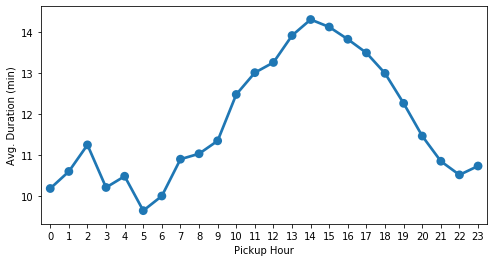

```python
plt.figure(figsize = [8, 4])
ax = sns.pointplot(data = bay_wheels_master, x = 'pickup_hour', y = 'duration', ci=None, estimator = np.median, color = base_color)
ax.set_xlabel('Pickup Hour')
ax.set_ylabel('Avg. Duration (min)')
plt.show()
```

> - We saw in the previous investigation that the average trip duration is about `12.7 mins`. Interestingly, this plot showed that the average trip duration depended on the time the users picked up the bike. Users tended to spend longer time on the trip than average when they picked up the bike in the afternoon, between 1pm to 3pm.

### Take a look at some of the relationships between the categorical variables

#### Member vs. Casual

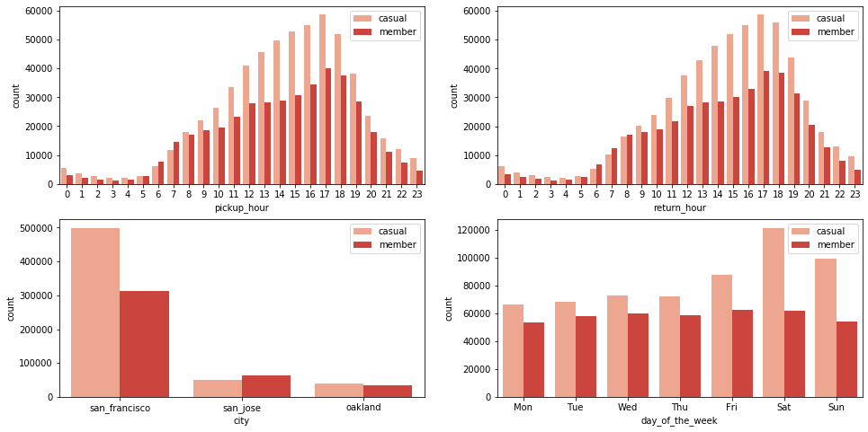

```python
plt.figure(figsize = [16, 8])

ax = plt.subplot(2, 2, 1)
sns.countplot(data = bay_wheels_master, x = 'pickup_hour', hue = 'member_casual', palette = 'Reds')
ax.legend()

ax = plt.subplot(2, 2, 2)
sns.countplot(data = bay_wheels_master, x = 'return_hour', hue = 'member_casual', palette = 'Reds')
ax.legend()

ax = plt.subplot(2, 2, 3)
sns.countplot(data = bay_wheels_master, x = 'city', hue = 'member_casual', palette = 'Reds')
ax.legend()

ax = plt.subplot(2, 2, 4)
sns.countplot(data = bay_wheels_master, x = 'day_of_the_week', hue = 'member_casual', palette = 'Reds')
ax.legend()

plt.show()
```

> - There is a similar pattern for both member and casual throughout the day. However, I think it's worth to point out between 6am and 8am in the morning is the only period, where members are using the bikesharing service more than non-members, including picking up and returning the bikes. The presumable explanation is that majority of the the member users are using shared bike as a transportation to work. This statement is supported by the diagram below, by comparing weekdays and weekends activity between member and casual users.
> - Interestingly, the number of trips of member users are consistent every day in the week, whereas casual users have a significant high number of trips on Saturday compared to other days.

#### Weekdays vs. Weekends

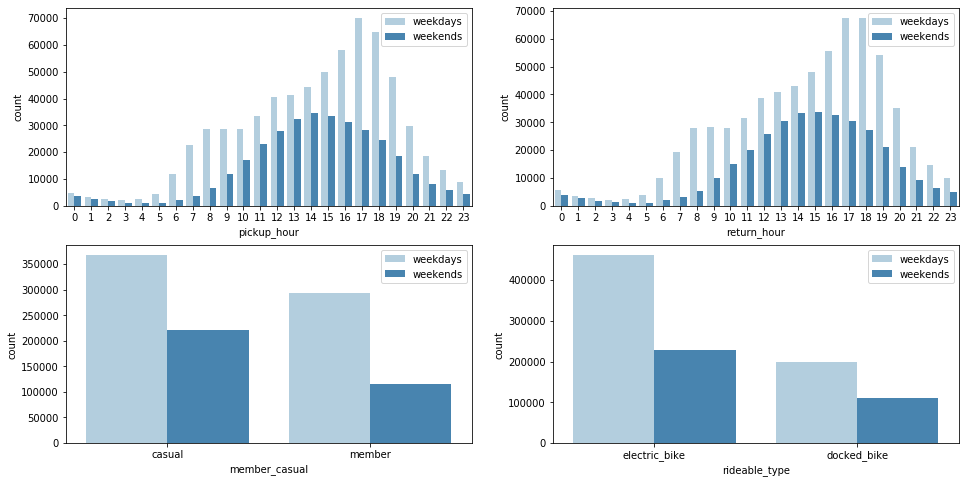

```python
plt.figure(figsize = [16, 8])

ax = plt.subplot(2, 2, 1)
sns.countplot(data = bay_wheels_master, x = 'pickup_hour', hue = 'week_period', palette = 'Blues')
ax.legend()

ax = plt.subplot(2, 2, 2)
sns.countplot(data = bay_wheels_master, x = 'return_hour', hue = 'week_period', palette = 'Blues')
ax.legend()

ax = plt.subplot(2, 2, 3)
sns.countplot(data = bay_wheels_master, x = 'member_casual', hue = 'week_period', palette = 'Blues')
ax.legend()

ax = plt.subplot(2, 2, 4)
sns.countplot(data = bay_wheels_master, x = 'rideable_type', hue = 'week_period', palette = 'Blues')
ax.legend()

plt.show()
```

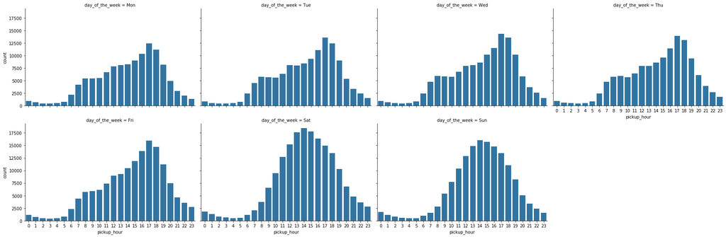

```python
g = sns.FacetGrid(data = bay_wheels_master, col = 'day_of_the_week', col_wrap = 4, height = 4, aspect = 1.5)
g.map(sns.countplot, 'pickup_hour', order = np.sort(bay_wheels_master['pickup_hour'].unique()))
g.set_ylabels('count');
```

> - There is a distinct pattern for weekdays and weekends.

#### Electric vs. Docked Bike

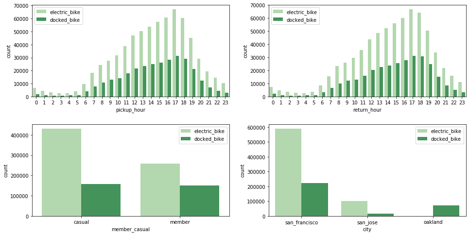

```python
fig = plt.figure(figsize = [16, 8])
fig.subplots_adjust(hspace=0.3)

ax = plt.subplot(2, 2, 1)
sns.countplot(data = bay_wheels_master, x = 'pickup_hour', hue = 'rideable_type', palette = 'Greens')
ax.legend()

ax = plt.subplot(2, 2, 2)
sns.countplot(data = bay_wheels_master, x = 'return_hour', hue = 'rideable_type', palette = 'Greens')
ax.legend()

ax = plt.subplot(2, 2, 3)
sns.countplot(data = bay_wheels_master, x = 'member_casual', hue = 'rideable_type', palette = 'Greens')
ax.legend()

ax = plt.subplot(2, 2, 4)
sns.countplot(data = bay_wheels_master, x = 'city', hue = 'rideable_type', palette = 'Greens')
ax.legend()

plt.show()
```

> - The usage of electric bike almost twice more frequent than docked bike for every hours of the day.
> - The proprotion of docked bike is higher for people with membership.
> - There is no electric bike in Oakland. The number of people used electric bike is three times the number of people used docked bike in San Francisco. And the difference is even larger in San Jose. Electric bike is more popular in California. This statement is validated by the first two diagrams about the hourly pattern.

### Talk about some of the relationships you observed in this part of the investigation. How did the feature(s) of interest vary with other features in the dataset?

> All categories have a very large range of duration except electric_bike. Interestingly, the average duration of the trip is similar and approximately 12 minutes no matter where the starting point is, when the trip is, who the user is and which type of the bike is. In fact, users tends to spend longer time on the trip when they pick up the bike in the afternoon.

### Did you observe any interesting relationships between the other features (not the main feature(s) of interest)?

> - Between 6am and 8am in the morning is the only period, where members are using the bikesharing service more than non-members, including picking up and returning the bikes.
> - Interestingly, the number of trips of member users are consistent every day in the week, whereas casual users have a significant high number of trips on Saturday compared to other days.
> - On the weekdays, the peak is at around 5pm to 6pm and this is the off-work time for most of the people. On the other hand, most of the trips are from 1pm to 3pm on the weekends, which is not the same as the overall daily pattern.
> - The usage of electric bike almost twice more frequent than docked bike for every hours of the day.

## Multivariate Exploration

> In the section, I investigate the data even further by creating plots of three or more variables.

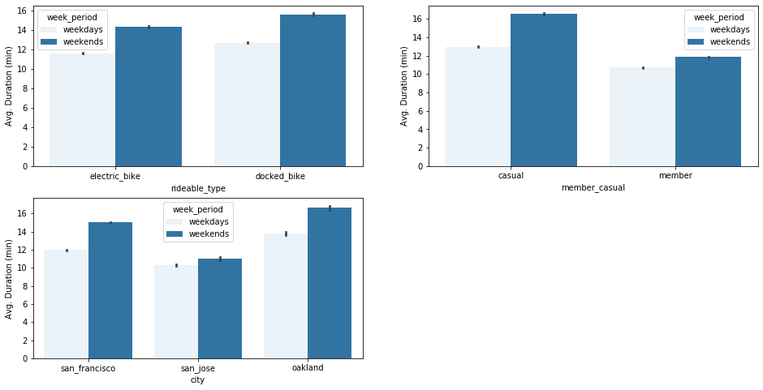

```python
plt.figure(figsize = [16, 8])
fig.subplots_adjust(hspace=0.3)

# A point plot shows the mean value by default
# In order use median as the estimate of central tendency, I used median module from numpy library
ax = plt.subplot(2, 2, 1)
ax = sns.barplot(data = bay_wheels_master, x = 'rideable_type', y = 'duration', hue = 'week_period', estimator=np.median, color = base_color)
# ax = sns.pointplot(data = df_master_clean, x = 'rideable_type', y = 'duration', hue = 'week_period', ci = None, dodge = 0.1, linestyles='', estimator = median, color = base_color)
ax.set_ylabel('Avg. Duration (min)')

ax = plt.subplot(2, 2, 2)
ax = sns.barplot(data = bay_wheels_master, x = 'member_casual', y = 'duration', hue = 'week_period', estimator=np.median, color = base_color)
ax.set_ylabel('Avg. Duration (min)')

ax = plt.subplot(2, 2, 3)
ax = sns.barplot(data = bay_wheels_master, x = 'city', y = 'duration', hue = 'week_period', estimator=np.median, color = base_color)
ax.set_ylabel('Avg. Duration (min)')

plt.show()
```

> - Diagrams above shows the relationship between one numeric variable and two categorical variables. All the dark blue bars are taller than its adjacent light blue bar, which means that people have in average longer trip duration on the weekends.
> - Oakland users spend longer time on a bike trip on the weekends compared to users in San Francisco and San Jose.

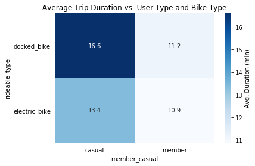

```python
cat_means = bay_wheels_master.groupby(['member_casual', 'rideable_type']).median()['duration']
cat_means = cat_means.reset_index(name = 'avg_duration')
cat_means = cat_means.pivot(index = 'rideable_type', columns = 'member_casual',
                            values = 'avg_duration')
s = sns.heatmap(cat_means, annot = True, fmt = '.1f', cmap = 'Blues',
                cbar_kws = {'label' : 'Avg. Duration (min)'})
s.set_yticklabels(s.get_yticklabels(), rotation = 0)
s.set_title('Average Trip Duration vs. User Type and Bike Type')
plt.show();
```

> - Casual users having a longer trip compared to member users in average.
> - Electric bikes generally are used for a shorter distance trip, whereas the users prefer docked bike for a longer distance trip.

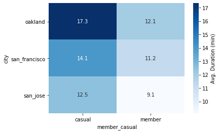

```python
cat_means = bay_wheels_master.groupby(['member_casual', 'city']).median()['duration']
cat_means = cat_means.reset_index(name = 'avg_duration')
cat_means = cat_means.pivot(index = 'city', columns = 'member_casual',
                            values = 'avg_duration')
s = sns.heatmap(cat_means, annot = True, fmt = '.1f', cmap = 'Blues',
                cbar_kws = {'label' : 'Avg. Duration (min)'})
s.set_yticklabels(s.get_yticklabels(), rotation = 0)
plt.show();
```

> - From this diagram we can see that people in Oakland are having the trip for a longer duration compared to other two cities. This can be explained that because there are so far no electric bikes available in Oakland, as we've seen from bivariate exploration.

Now, I created a `catplot()` to explore the relationship between the one numeric variable `duration` and three categorical variables `rideable_type`, `week_period` and `member_casual`, as it would give me more insights about the interaction effects between these variables.

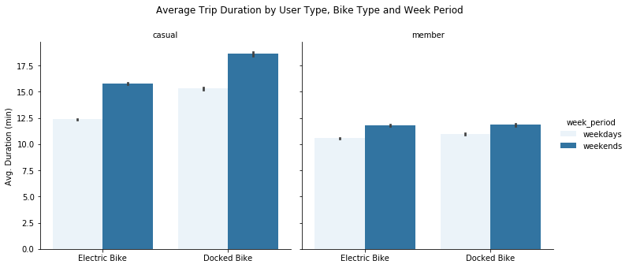

```python
g = sns.catplot(x='rideable_type', y='duration',
                hue="week_period", col='member_casual',
                data=bay_wheels_master, kind="bar", estimator=np.median, color = base_color)
(g.set_axis_labels('', 'Avg. Duration (min)')
  .set_titles("{col_name}")
  .set_xticklabels(['Electric Bike', 'Docked Bike']))
plt.subplots_adjust(top=0.85)
g.fig.suptitle('Average Trip Duration by User Type, Bike Type and Week Period')
plt.show()
```

> - Interestingly, the duration of the trips taken with electric and docked bike by the member users were very similar. The difference in duration between weekdays and weekends for each type of bike was not significant either.

To dive deeper into the exploration, I created pointplots to show the relationship between `duration` and `day_of_the_week`, additionally with `member_casual` or `rideable_type`.

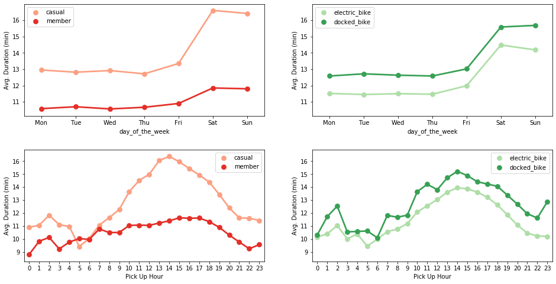

```python
fig = plt.figure(figsize = [16, 8])
fig.subplots_adjust(hspace=0.3)

ax1 = plt.subplot(2, 2, 1)
ax1 = sns.pointplot(data = bay_wheels_master, x = 'day_of_the_week', y = 'duration', hue = 'member_casual', ci=None, estimator = np.median, palette = 'Reds')
ax1.set_ylabel('Avg. Duration (min)')
ax1.legend()

ax2 = plt.subplot(2, 2, 2)
ax = sns.pointplot(data = bay_wheels_master, x = 'day_of_the_week', y = 'duration', hue = 'rideable_type', ci=None, estimator = np.median, palette = 'Greens')
ax2.set_ylabel('Avg. Duration (min)')
ax2.legend()
ax2.set_ylim(ax1.get_ylim())

ax3 = plt.subplot(2, 2, 3)
ax3 = sns.pointplot(data = bay_wheels_master, x = 'pickup_hour', y = 'duration', hue = 'member_casual', ci=None, estimator = np.median, palette = 'Reds')
ax3.set_xlabel('Pick Up Hour')
ax3.set_ylabel('Avg. Duration (min)')
ax3.legend()

ax4 = plt.subplot(2, 2, 4)
ax4 = sns.pointplot(data = bay_wheels_master, x = 'pickup_hour', y = 'duration', hue = 'rideable_type', ci=None, estimator = np.median, palette = 'Greens')
ax4.set_xlabel('Pick Up Hour')
ax4.set_ylabel('Avg. Duration (min)')
ax4.legend()
ax4.set_ylim(ax3.get_ylim())

plt.show()
```

> - Generally, users spend longer time for a trip on Saturday and Sunday.
> - Clearly visible is that the average duration difference of trip between casual and member users is significant larger on the weekends.
> - The average duration spent by the casual users, electric bikes users and docked bikes users show similar pattern throughout the day. They spend the longest time if they pick the bike at 2pm.
> - Interesting, member users spend similar average duration on a bike trip, with approximately 9 to 11 minutes, no matter what time they pick up the bike.

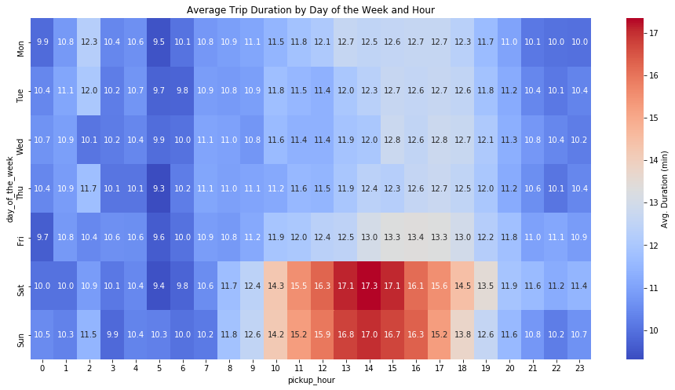

```python
pivot = bay_wheels_master.pivot_table(values = 'duration', index = 'day_of_the_week', columns = 'pickup_hour', aggfunc='median')
plt.figure(figsize = [16,8])
sns.heatmap(pivot, annot=True, fmt='.1f', cbar_kws = {'label': 'Avg. Duration (min)'}, cmap = 'coolwarm')
plt.title('Average Trip Duration by Day of the Week and Hour');
```

> - Here we can clearly see that the average trip duration is higher than the median value on the weekends between 10am to 18pm .

I used the latitude/longitude to see where rentings are mostly concentrated in San Francisco.

```python
bay_wheels_master_sf = bay_wheels_master[bay_wheels_master['city']=='san_francisco']
data = bay_wheels_master_sf.groupby(['start_lng', 'start_lat']).count()['ride_id']
data = pd.DataFrame(data.reset_index(name='number_of_trips'))
```

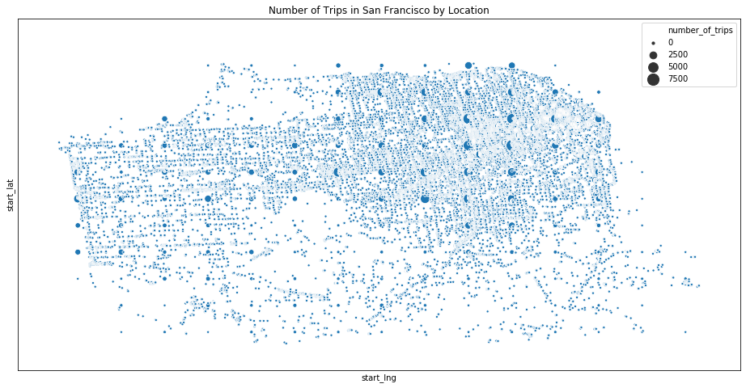

```python
plt.figure(figsize=[16,8])
sns.scatterplot(x='start_lng', y='start_lat', size = 'number_of_trips', sizes = (10,200), data=data)
plt.title('Number of Trips in San Francisco by Location')
plt.yticks([])
plt.xticks([])
plt.legend();
```

### Talk about some of the relationships you observed in this part of the investigation. Were there features that strengthened each other in terms of looking at your feature(s) of interest?

> - People have in average longer trip duration on the weekends
> - Casual users having a longer trip compared to member users in average.
> - Electric bikes generally are used for a shorter distance trip, whereas the users prefer docked bike for a longer distance trip.
> - People in Oakland are having the trip for a longer duration compared to other two cities. This can be explained that because there are so far no electric bikes available in Oakland

### Were there any interesting or surprising interactions between features?

> - Interestingly, the trips taken with electric and docked bike by the member users are very similar in duration, when we look at weekdays only data or weekends only data.
> - The average duration difference of trip between casual and member users is significant larger on the weekends.
> - The average duration spent by the casual users, electric bikes users and docked bikes users show similar pattern throughout the day. They spend the longest time if they pick the bike at 2pm.

```python
# Generate .html file in the workspace directory
from subprocess import call
call(['python', '-m', 'nbconvert', 'Exploratory_Analysis.ipynb'])
```

```
0
```